# Regression Models - Course Project

Lorena Zuniga

#### Executive Summary

For this project, Motor Trend (a magazine about the automobile industry) is interested in exploring the relationship between a set of variables and miles per gallon (MPG). They need to answer the following questions: 1- Is an automatic or manual transmission better for MPG ? 2- Quantify the MPG difference between automatic and manual transmissions This project use the mtcars dataset

#### Exploratory Analysis

Load the data:

```r
data("mtcars")
str(mtcars)
```

[output not shown]

In the am column: 0 is automatic transmission, 1 = manual transmission. It is observed that the MPG mean between each type of transmission is different:

```r
 autom<- mtcars[mtcars$am==0,]
 manual <-mtcars[mtcars$am==1,]
 c(mean(autom$mpg),mean(manual$mpg))
```

```
## [1] 17.15 24.39
```

#### Inference

It is necessary to determine if the MPG mean difference is significant, then we can perform a t-test. Alpha value =0.05

```r
 t.test(autom$mpg,manual$mpg)
```

[output not shown]

The p-value is 0.001374, so in this case the difference between the MPG mean of the cars with manual transmission and the automatic cars is significant

#### Regression Analysis

At first we cant test a simple linear regression model using am as predictor and mpg as outcome

```r
  summary(lm(mpg ~ am, data=mtcars))$coef
```

```
##             Estimate Std. Error t value  Pr(>|t|)
## (Intercept)   17.147      1.125  15.247 1.134e-15
## am             7.245      1.764   4.106 2.850e-04
```

#### Multivariable linear regression

In order to know which variables could be better to include in the multivariable linear regression model, we can get a correlation matrix, as follows:

```r
  cor(mtcars)[1,]
```

[output not shown]

From the resultant matrix we can say that wt and hp could be tested as predictors

```r
  simpleModel <- lm(mpg ~ am,data=mtcars)
  multiModel <- lm(mpg ~ am + hp + wt, data=mtcars)
```

Comparing both models with ANOVA:

```r
  anova(simpleModel, multiModel)
```

[output not shown]

The p-value is 3.7e-09 and therefore the difference between both models is significant

```r
 summary(multiModel)$coef
```

```
##             Estimate Std. Error t value  Pr(>|t|)
## (Intercept) 34.00288   2.642659  12.867 2.824e-13
## am           2.08371   1.376420   1.514 1.413e-01
## hp          -0.03748   0.009605  -3.902 5.464e-04
## wt          -2.87858   0.904971  -3.181 3.574e-03
```

Observing the coefficients, it is possible to say that, in average, cars with manual transmission have 2.083MPG more than cars with automatic transmission. For the multivariable model the R-squared = 0.84, it is possible to say that the multivariable model explain the 84% of the variance.

#### Residuals

It is verified that the mean of the residuals is near 0:

```r
  mean(multiModel$residuals)
```

```
## [1] 1.561e-16
```

Also it is possible verify that each one of the MPG predictors (hp, wt and am) are uncorrelated with the residuals The residuals chart can be found in the Apendix

```r
  cov(multiModel$residuals,mtcars$hp)
```

```
## [1] -2.268e-14
```

```r
  cov(multiModel$residuals,mtcars$wt)
```

```
## [1] -3.798e-16
```

```r
  cov(multiModel$residuals,mtcars$am)
```

```
## [1] 8.846e-17
```

#### Apendix

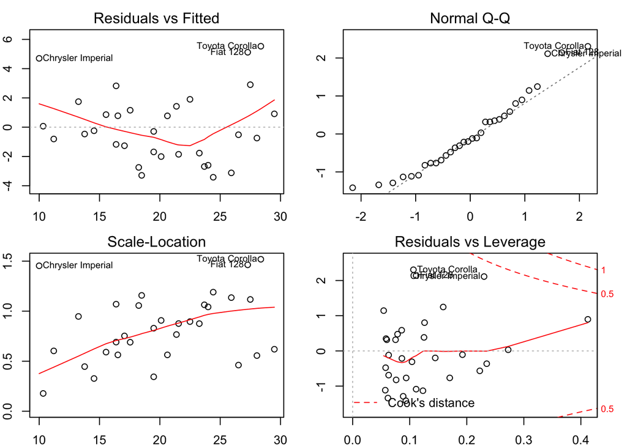

```r
   par(mfrow=c(2,2))
   par(mar=rep(2,4))
   plot(multiModel)
```

The complete code for this project can be found here: (https://github.com/lorenazs/regressionmodels/blob/master/Project/project.Rmd)